# R Notebook

```r
library(tidyverse)
library(conflicted)
library(magrittr)
```

# Part one

```r
df <- readxl::read_xlsx("Data_source.xlsx")
df
```

| Id | ethnicgp | gender | age | years | commit | satis | autonom | routine | attend | skill | prody | qual | absence | income |
| --- | --- | --- | --- | --- | --- | --- | --- | --- | --- | --- | --- | --- | --- | --- |
| 1 | 1 | 1 | 29 | 1 | 4 | NA | 10 | 9 | 2 | 3 | NA | 1 | 7 | 16.6 |
| 2 | 2 | 1 | 26 | 5 | 2 | NA | 7 | 15 | 1 | 3 | 4 | 4 | 8 | 14.6 |
| 3 | 3 | 1 | 40 | 5 | 4 | 15 | 7 | 8 | 1 | 4 | 3 | 4 | 0 | 17.8 |
| 4 | 3 | 1 | 46 | 15 | 2 | 7 | 7 | 10 | 2 | 3 | 3 | 4 | 4 | 16.4 |
| 5 | 2 | 2 | 63 | 36 | 4 | 14 | 11 | 18 | 1 | 3 | 5 | 3 | 0 | 18.6 |
| 6 | 1 | 1 | 54 | 31 | 2 | 9 | 6 | 16 | 1 | 1 | 3 | 4 | 1 | 16.0 |
| 7 | 1 | 1 | 29 | 2 | NA | 11 | 9 | 14 | 2 | 3 | 5 | 2 | 0 | 16.6 |
| 8 | 3 | 1 | 35 | 2 | 5 | 14 | 12 | 11 | 2 | 3 | 4 | 4 | 2 | 17.6 |
| 9 | 2 | 2 | 33 | 4 | 3 | 12 | 10 | 9 | 2 | 2 | 1 | 1 | 5 | 17.6 |
| 10 | 2 | 2 | 27 | 6 | 4 | 13 | 8 | 15 | 1 | 2 | 2 | 4 | 4 | 13.8 |

[output cut: 60 more lines]

ethnicgp = ethnic group, 1 = White, 2 = Asian, 3 = West Indian, 4 = African, 5 = other gender (male =1, female =2), income = gross annual income before tax in 1000£ age in years years = number of years working at this firm commit = organisational commitment (scale 1 ~ 5) satis = job satisfaction autonom = job autonomy routine = job routine attend = attendance at meeting (yes = 1, no = 2) skill = rated skill (unskilled, semi-skilled, fairly skilled, highly skilled, 1 ~ 4) prody = rated productivity (very poor, poor, average, good, very good, 1 ~ 5) qual = rated quality (very poor, poor, average, good, very good, 1 ~ 5) absence = days of being absent in last 12 months

```r
dff <- df %>%
  mutate(
    ethnicgp = as_factor(ethnicgp) %>% fct_recode("White" = "1", "Asian" = "2", "West Indian" = "3", "African" = "4", "Other" = "5"),
    gender = as_factor(gender) %>% fct_recode("Male" = "1", "Female" = "2"),
    attend = as_factor(attend) %>% fct_recode("Yes" = "1", "No" = "2"),
    skill = as.ordered(skill) %>% fct_recode("Unskilled" = "1", "Semi-skilled" = "2", "Fairly skilled" = "3", "Highly skilled" = "4"),
    prody = as.ordered(prody) %>% fct_recode("Very poor" = "1", "Poor" = "2", "Average" = "3", "Good" = "4", "Very good" = "5"),
    qual = as.ordered(qual) %>% fct_recode("Very poor" = "1", "Poor" = "2", "Average" = "3", "Good" = "4", "Very good" = "5"),
    commit = as.ordered(commit), #  TODO ask if the ordinal variables (likert scale i think) should be treated as numeric or as factor or as ordinal (or some other thing)
    # satis = satis %>% as.ordered(), # without the complete context impossible to tell, deciding to treat them as numeric bcs it might be an internal calculation. Unusual for satisfaction, but it fits with autonom and routine, which follow a similar scheme (and scale)


  )
dff$ethnicgp |> attr("label") <- "number of years working at this firm"
dff$commit |> attr("label") <- "organisational commitment (1 to 5)"
dff$satis |> attr("label") <- "job satisfaction"
dff$autonom |> attr("label") <- "job autonomy"
dff$routine |> attr("label") <- "job routine"
dff$attend |> attr("label") <- "attendance at meeting"
dff$prody |> attr("label") <- "rated productivity"
dff$qual |> attr("label") <- "rated quality"
dff$absence |> attr("label") <- "days of being absent in last 12 months"
dff$years |> attr("label") <- "number of years working at this firm"
dff$income |> attr("label") <- "Gross anual income/1000£"
dff
```

| Id | ethnicgp | gender | age | years | commit | satis | autonom | routine | attend | skill | prody | qual | absence | income |
| --- | --- | --- | --- | --- | --- | --- | --- | --- | --- | --- | --- | --- | --- | --- |
| 1 | White | Male | 29 | 1 | 4 | NA | 10 | 9 | No | Fairly skilled | NA | Very poor | 7 | 16.6 |
| 2 | Asian | Male | 26 | 5 | 2 | NA | 7 | 15 | Yes | Fairly skilled | Good | Good | 8 | 14.6 |
| 3 | West Indian | Male | 40 | 5 | 4 | 15 | 7 | 8 | Yes | Highly skilled | Average | Good | 0 | 17.8 |
| 4 | West Indian | Male | 46 | 15 | 2 | 7 | 7 | 10 | No | Fairly skilled | Average | Good | 4 | 16.4 |
| 5 | Asian | Female | 63 | 36 | 4 | 14 | 11 | 18 | Yes | Fairly skilled | Very good | Average | 0 | 18.6 |
| 6 | White | Male | 54 | 31 | 2 | 9 | 6 | 16 | Yes | Unskilled | Average | Good | 1 | 16.0 |
| 7 | White | Male | 29 | 2 | NA | 11 | 9 | 14 | No | Fairly skilled | Very good | Poor | 0 | 16.6 |
| 8 | West Indian | Male | 35 | 2 | 5 | 14 | 12 | 11 | No | Fairly skilled | Good | Good | 2 | 17.6 |
| 9 | Asian | Female | 33 | 4 | 3 | 12 | 10 | 9 | No | Semi-skilled | Very poor | Very poor | 5 | 17.6 |
| 10 | Asian | Female | 27 | 6 | 4 | 13 | 8 | 15 | Yes | Semi-skilled | Poor | Good | 4 | 13.8 |

[output cut: 60 more lines]

## 1.1

### a)

Make plot of gender in Bar chart and ethnic group in pie diagram

```r
library(janitor)
dff %>% tabyl(gender) %>%
  adorn_pct_formatting(affix_sign = F)
```

```
 gender  n percent
   Male 39    55.7
 Female 31    44.3
```

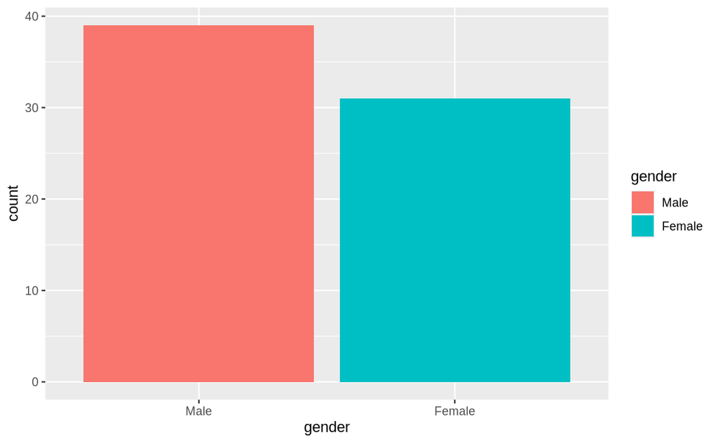

```r
dff %>% ggplot(aes(x = gender, fill = gender)) +
  geom_bar()
```

```r
dff %>%
  tabyl(ethnicgp) %>%
  adorn_pct_formatting(affix_sign = F) -> etnias
etnias
```

```
    ethnicgp  n percent
       White 36    51.4
       Asian 18    25.7
 West Indian 14    20.0
     African  2     2.9
```

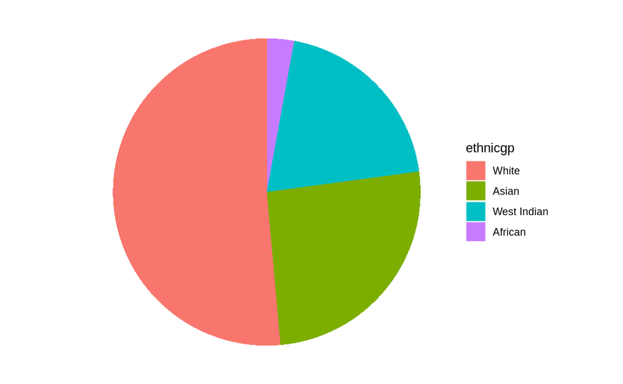

```r
etnias %>% as.data.frame() %>%
  ggplot(aes(x = "", y = n, fill = ethnicgp)) +
  geom_bar(stat = "identity") +
  coord_polar("y", start = -0) +
  theme_void()
```

### b)

Make a five number summary (max, min, median, the first and third quartiles) of Age then a box-plot

```r
summary(dff$age)
```

```
   Min. 1st Qu.  Median    Mean 3rd Qu.    Max.    NA's
  18.00   29.00   39.00   39.19   50.00   63.00       1
```

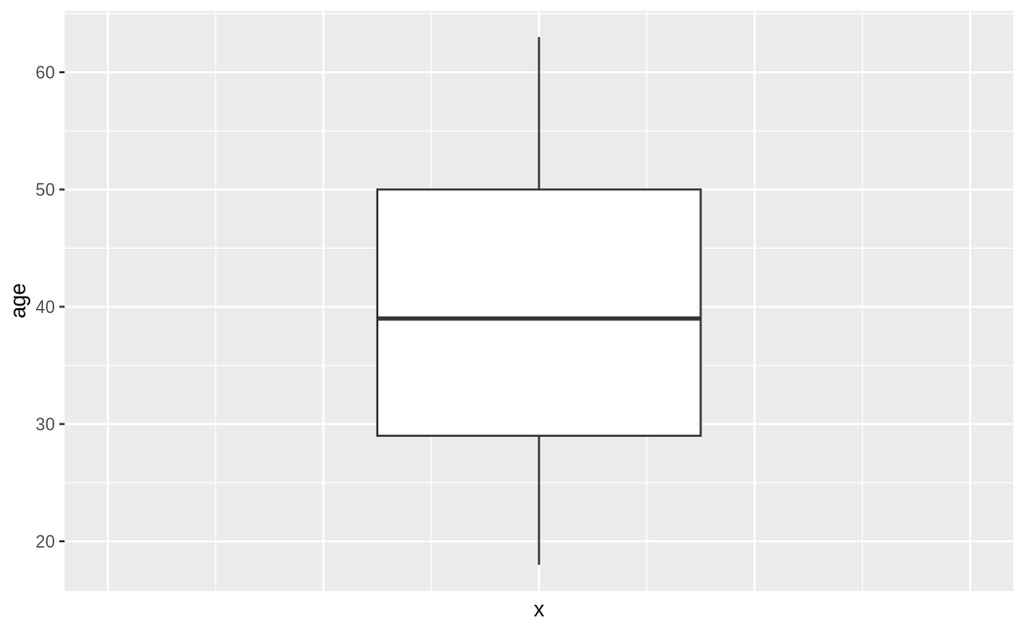

```r
dff %>% ggplot(aes(y= age, x = 0)) +
  geom_boxplot() +
  xlim(-1, 1) +
  theme(axis.text.x = element_blank(), axis.ticks.x= element_blank(), axis.x = element_blank())
```

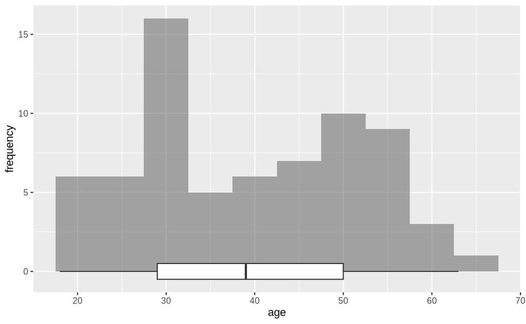

```r
dff %>% ggplot(aes(x = age)) +
  geom_histogram(bins = 10, alpha = 0.5) +
  geom_boxplot(aes(y = 0), width = 1) +
  ylab("frequency")
```

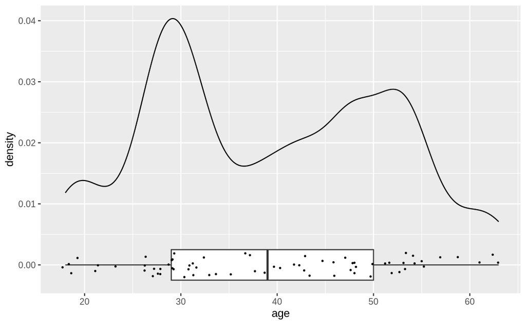

```r
dff %>% ggplot(aes(x = age)) +
  geom_density(adjust =0.5,  alpha = 0.5) +
  geom_boxplot(aes(y = 0), width = 0.005) +
  geom_jitter(aes(y = 0), height = 0.002, size = 0.4) +
  ylab("density")
```

### c)

Find the mean and standard deviation of income, and as well as histogram of it.

```r
cat("mean income = ", mean(dff$income, na.rm = T), "standard deviation = ", sd(dff$income, na.rm = T), "\n")
```

```
mean income =  15.63824 standard deviation =  1.995894
```

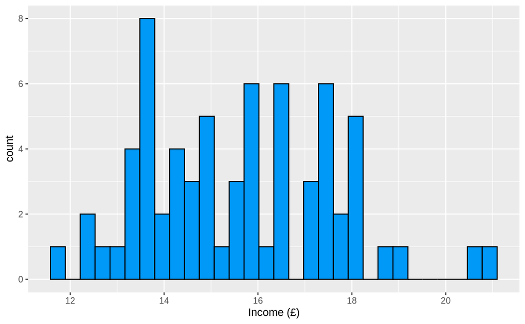

```r
dff %>% ggplot(aes(income)) +
  geom_histogram(color = "#000000", fill = "#0099F8") +
  xlab("Income (£)")
```

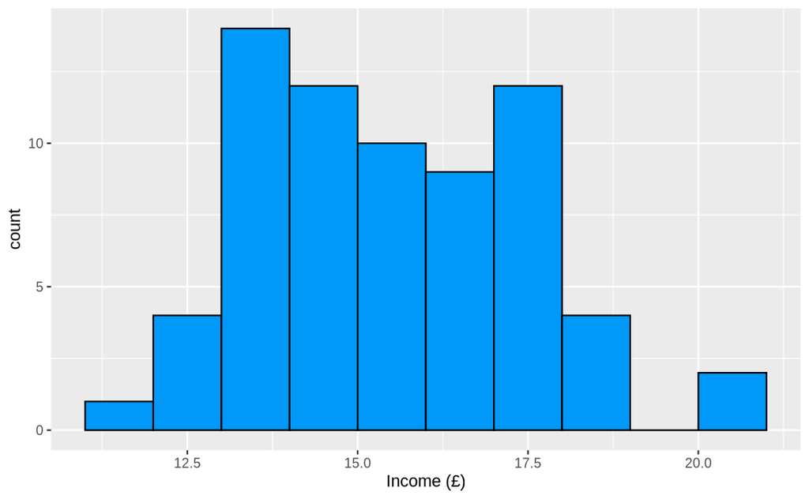

```r
dff %>% ggplot(aes(income)) +
  # https://en.wikipedia.org/wiki/Sturges%27s_rule
  geom_histogram(breaks = hist(dff$income, plot = F, breaks = "Sturges")$breaks, color = "#000000", fill = "#0099F8") +
  xlab("Income (£)")
```

## 1.2

Consider the variables income and absence. ### a) Make scatter plot to visualize the relationship between them

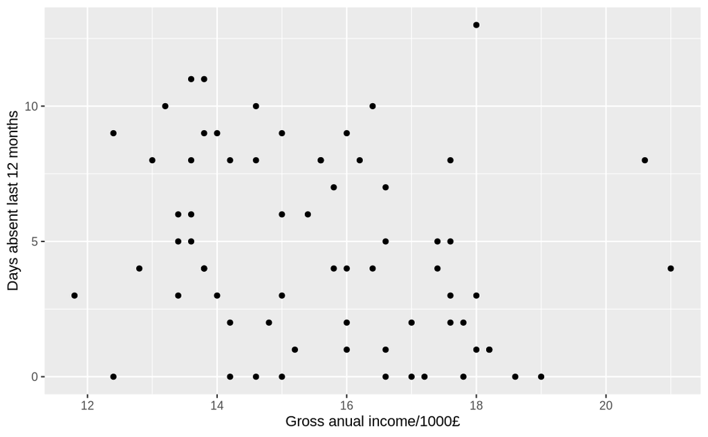

```r
dffr <- dff %>% rename(`Days absent last 12 months` = absence, `Gross anual income/1000£` = income)

dffr %>% ggplot(aes(y = `Days absent last 12 months`, x= `Gross anual income/1000£`)) +
  geom_point()
```

### b)

```r
# TODO ask if they mean linear regression
dffr %>% lm(`Days absent last 12 months` ~ `Gross anual income/1000£`, data = .) %>% summary
```

```
Call:
lm(formula = `Days absent last 12 months` ~ `Gross anual income/1000£`,
    data = .)

Residuals:
    Min      1Q  Median      3Q     Max
-6.0923 -2.6528 -0.5689  2.8036  9.3506

Coefficients:
                           Estimate Std. Error t value Pr(>|t|)
(Intercept)                 11.5016     3.3093   3.476 0.000913 ***
`Gross anual income/1000£`  -0.4362     0.2097  -2.080 0.041426 *
---
Signif. codes:  0 ‘***’ 0.001 ‘**’ 0.01 ‘*’ 0.05 ‘.’ 0.1 ‘ ’ 1

Residual standard error: 3.416 on 65 degrees of freedom
  (3 observations deleted due to missingness)
Multiple R-squared:  0.06243,   Adjusted R-squared:  0.04801
F-statistic: 4.328 on 1 and 65 DF,  p-value: 0.04143
```

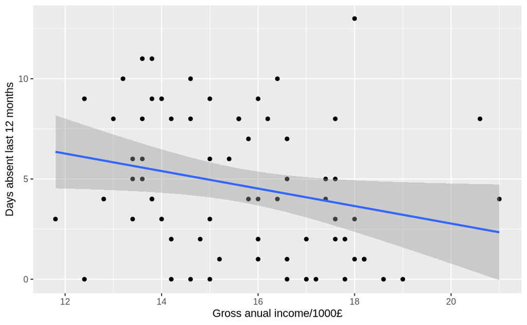

```r
# dffr %>% loess(`Days absent last 12 months` ~ `Gross anual income/1000£`, data = .) %>% summary
dffr %>% ggplot(aes(y = `Days absent last 12 months`, x= `Gross anual income/1000£`)) +
  geom_point() +
  geom_smooth(method = "lm")
```

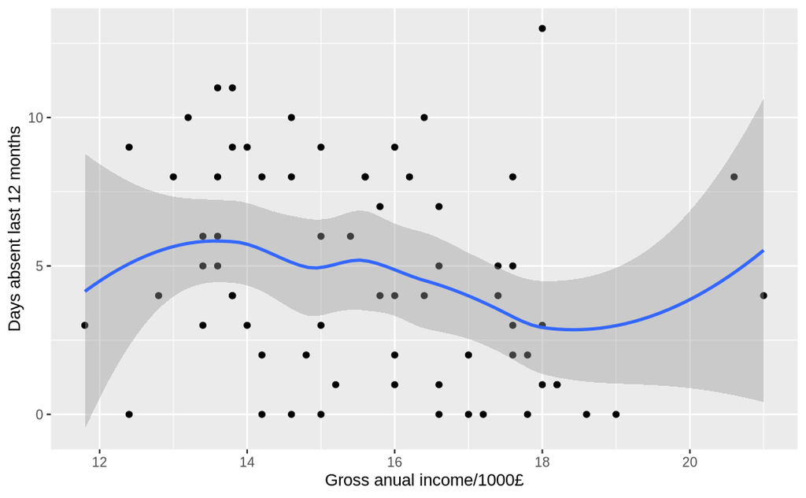

```r
dffr %>% ggplot(aes(y = `Days absent last 12 months`, x= `Gross anual income/1000£`)) +
  geom_point() +
  geom_smooth()
```

## 1.3

Study the multiple regression model with satis as dependent variable and commit, autonom, income, skill, rated quality, age, years as independent variables

```r
dff %>% lm(satis ~ commit + autonom + income + skill + qual + age + years, data = .) %>% summary -> lm_result
lm_result
```

```
Call:
lm(formula = satis ~ commit + autonom + income + skill + qual +
    age + years, data = .)

Residuals:
    Min      1Q  Median      3Q     Max
-3.0011 -0.8110 -0.2268  0.7923  2.7636

Coefficients:
            Estimate Std. Error t value Pr(>|t|)
(Intercept)  0.60665    2.31207   0.262 0.794198
commit.L     2.77638    0.77623   3.577 0.000832 ***
commit.Q    -0.56056    0.54513  -1.028 0.309189
commit.C    -1.06017    0.47040  -2.254 0.029019 *
commit^4    -0.28105    0.42073  -0.668 0.507476
autonom      0.40253    0.09665   4.165 0.000136 ***
income       0.37735    0.17148   2.201 0.032823 *
skill.L      1.22153    0.44913   2.720 0.009187 **
skill.Q      0.54645    0.43314   1.262 0.213453
skill.C      0.09794    0.45115   0.217 0.829105
qual.L       0.89886    0.54005   1.664 0.102829
qual.Q      -0.33446    0.50982  -0.656 0.515068
qual.C      -0.40541    0.46480  -0.872 0.387615
qual^4       0.05428    0.47839   0.113 0.910154
age          0.02268    0.03884   0.584 0.562072
years       -0.01938    0.03486  -0.556 0.580953
---
Signif. codes:  0 ‘***’ 0.001 ‘**’ 0.01 ‘*’ 0.05 ‘.’ 0.1 ‘ ’ 1

Residual standard error: 1.514 on 46 degrees of freedom
  (8 observations deleted due to missingness)
Multiple R-squared:  0.8414,    Adjusted R-squared:  0.7896
F-statistic: 16.26 on 15 and 46 DF,  p-value: 1.391e-13
```

### a)

Which variables among them do NOT have any significant impact on satis ?

```r
lm_result$coefficients %>% as.data.frame %>% arrange(Estimate %>% abs)
```

|  | Estimate | Std. Error | t value | Pr(>\|t\|) |
| --- | --- | --- | --- | --- |
| years | -0.01938134 | 0.03486294 | -0.5559296 | 0.5809531456 |
| age | 0.02268003 | 0.03883551 | 0.5840024 | 0.5620718038 |
| qual^4 | 0.05428206 | 0.47839284 | 0.1134675 | 0.9101536653 |
| skill.C | 0.09793502 | 0.45114584 | 0.2170806 | 0.8291054835 |
| commit^4 | -0.28104632 | 0.42073227 | -0.6679933 | 0.5074758365 |
| qual.Q | -0.33446285 | 0.50982190 | -0.6560386 | 0.5150675270 |
| income | 0.37735407 | 0.17147740 | 2.2006053 | 0.0328229710 |
| autonom | 0.40253175 | 0.09665359 | 4.1646848 | 0.0001355658 |
| qual.C | -0.40540982 | 0.46479888 | -0.8722263 | 0.3876150086 |
| skill.Q | 0.54644779 | 0.43313905 | 1.2615990 | 0.2134532301 |

[output cut: 6 more lines]

### b)

Find a simpler multiple regression model with satis as dependent variable by deleting all those non-impact variables.

```r
dff %>% lm(satis ~ commit + autonom + income + skill + qual, data = .) %>% summary
```

```
Call:
lm(formula = satis ~ commit + autonom + income + skill + qual,
    data = .)

Residuals:
    Min      1Q  Median      3Q     Max
-3.1919 -0.8029 -0.1391  0.7562  2.7990

Coefficients:
            Estimate Std. Error t value Pr(>|t|)
(Intercept) -0.42095    2.07008  -0.203 0.839686
commit.L     2.80529    0.71930   3.900 0.000287 ***
commit.Q    -0.74378    0.52125  -1.427 0.159820
commit.C    -0.92899    0.45261  -2.053 0.045371 *
commit^4    -0.37218    0.41354  -0.900 0.372446
autonom      0.41974    0.09208   4.558 3.35e-05 ***
income       0.47042    0.12075   3.896 0.000291 ***
skill.L      1.04710    0.43142   2.427 0.018865 *
skill.Q      0.46188    0.42080   1.098 0.277619
skill.C      0.02908    0.43441   0.067 0.946897
qual.L       0.82801    0.52583   1.575 0.121636
qual.Q      -0.14606    0.49297  -0.296 0.768240
qual.C      -0.37864    0.45621  -0.830 0.410498
qual^4      -0.08849    0.44775  -0.198 0.844135
---
Signif. codes:  0 ‘***’ 0.001 ‘**’ 0.01 ‘*’ 0.05 ‘.’ 0.1 ‘ ’ 1

Residual standard error: 1.503 on 50 degrees of freedom
  (6 observations deleted due to missingness)
Multiple R-squared:  0.8398,    Adjusted R-squared:  0.7982
F-statistic: 20.16 on 13 and 50 DF,  p-value: 1.714e-15
```